# **Assignment 1**

**Team Members**  
Veera Anand  
Aarav Dewangan  
Samuel Martinez Koss  
John Melel

Notes:

- Questions 01, 02, 03, 04 from `0001-01-02-02_performance-metrics_homework.html`
- Bonus Question from `0001-01-01-02_bias_vs_variance_homework.html`

```python
#All libraries are imported here
import pandas as pd
import numpy as np
from sklearn.metrics import accuracy_score, precision_score, recall_score, f1_score, log_loss
from sklearn.metrics import mean_absolute_error, mean_squared_error, r2_score, explained_variance_score, mean_absolute_percentage_error
import tensorflow as tf
import torch
import torch.nn.functional as F
from sklearn.linear_model import LassoLars
from sklearn.preprocessing import StandardScaler
import matplotlib.pyplot as plt
```

## **Question 01**

Datasets `binomial-classification-v1.csv` and `binomial-classification-v2.csv` contain actuals and predictions values from a binomial response variable.

1. Print one record containing a true/positive, true/negative, false/positive, false/negative
2. Manually compute `accuracy`, `precision`, `recall`, `f1_Score`
3. Compute the metrics in item 2 using `sklearn` and `tensorflow`, and `torch`
4. Show the values matching across all three computing approaches

### For binomial-classification-v1.csv (V1)

```python
v1_df = pd.read_csv('Data/binomial-classification-v1.csv')
v1_df = v1_df[['actual', 'predicted']]

print(v1_df.head())
```

```
   actual  predicted
0       1          0
1       0          1
2       1          0
3       0          1
4       1          0
```

```python
def compute_metrics(actual, predicted):
    TP = np.where((actual == 1) & (predicted == 1),1,0)
    TN = np.where((actual == 0) & (predicted == 0),1,0)
    FP = np.where((actual == 0) & (predicted == 1),1,0)
    FN = np.where((actual == 1) & (predicted == 0),1,0)
    metrics = pd.DataFrame()
    metrics["actual"] = actual
    metrics["predicted"] = predicted
    metrics["TP"] = TP
    metrics["TN"] = TN
    metrics["FP"] = FP
    metrics["FN"] = FN
    return metrics, TP, TN, FP, FN

v1_metrics, TP, TN, FP, FN = compute_metrics(v1_df['actual'], v1_df['predicted'])
display(v1_metrics.head())
```

|  | actual | predicted | TP | TN | FP | FN |
| --- | --- | --- | --- | --- | --- | --- |
| 0 | 1 | 0 | 0 | 0 | 0 | 1 |
| 1 | 0 | 1 | 0 | 0 | 1 | 0 |
| 2 | 1 | 0 | 0 | 0 | 0 | 1 |
| 3 | 0 | 1 | 0 | 0 | 1 | 0 |
| 4 | 1 | 0 | 0 | 0 | 0 | 1 |

```python
tn = v1_metrics.loc[v1_metrics['TN'] == 1][:1]
display(tn)
tp = v1_metrics.loc[v1_metrics['TP'] == 1][:1]
display(tp)
fn = v1_metrics.loc[v1_metrics['FN'] == 1][:1]
display(fn)
fp = v1_metrics.loc[v1_metrics['FP'] == 1][:1]
display(fp)
```

|  | actual | predicted | TP | TN | FP | FN |
| --- | --- | --- | --- | --- | --- | --- |
| 10 | 0 | 0 | 0 | 1 | 0 | 0 |

|  | actual | predicted | TP | TN | FP | FN |
| --- | --- | --- | --- | --- | --- | --- |
| 20 | 1 | 1 | 1 | 0 | 0 | 0 |

|  | actual | predicted | TP | TN | FP | FN |
| --- | --- | --- | --- | --- | --- | --- |
| 0 | 1 | 0 | 0 | 0 | 0 | 1 |

|  | actual | predicted | TP | TN | FP | FN |
| --- | --- | --- | --- | --- | --- | --- |
| 1 | 0 | 1 | 0 | 0 | 1 | 0 |

```python
TP = np.sum(TP)
TN = np.sum(TN)
FP = np.sum(FP)
FN = np.sum(FN)

# manual
accuracy_mn = (TP+TN)/(TP+TN+FP+FN)
precision_mn = (TP)/(TP+FP)
recall_mn = TP/(TP+FN)
f1_score_mn = 2*(precision_mn*recall_mn)/(precision_mn+recall_mn)
specificity_mn = TN/(TN+FP)

# sklearn
accuracy_skl = accuracy_score(v1_df['actual'], v1_df['predicted'])
precision_skl = precision_score(v1_df['actual'], v1_df['predicted'])
recall_skl = recall_score(v1_df['actual'], v1_df['predicted'])
f1_score_skl = f1_score(v1_df['actual'], v1_df['predicted'])

# tensorflow
accuracy = tf.keras.metrics.Accuracy()
accuracy.update_state(v1_df['actual'], v1_df['predicted'])
accuracy_tf = accuracy.result().numpy()

precision = tf.keras.metrics.Precision()
precision.update_state(v1_df['actual'], v1_df['predicted'])
precision_tf = precision.result().numpy()

recall = tf.keras.metrics.Recall()
recall.update_state(v1_df['actual'], v1_df['predicted'])
recall_tf = recall.result().numpy()

f1_score_TF = 2 * (precision_tf * recall_tf) / (precision_tf + recall_tf)


# torch
y_actual_tensor = torch.tensor(v1_df['actual'].values)
y_predic_tensor = torch.tensor(v1_df['predicted'].values)

TP_torch = ((y_actual_tensor == 1) & (y_predic_tensor == 1)).sum().item()
TN_torch = ((y_actual_tensor == 0) & (y_predic_tensor == 0)).sum().item()
FP_torch = ((y_actual_tensor == 0) & (y_predic_tensor == 1)).sum().item()
FN_torch = ((y_actual_tensor == 1) & (y_predic_tensor == 0)).sum().item()

accuracy_torch = (TP_torch + TN_torch) / (TP_torch + TN_torch + FP_torch + FN_torch)
precision_torch = TP_torch / (TP_torch + FP_torch) if (TP_torch + FP_torch) > 0 else 0
recall_torch = TP_torch / (TP_torch + FN_torch) if (TP_torch + FN_torch) > 0 else 0
f1_score_torch = 2 * (precision_torch * recall_torch) / (precision_torch + recall_torch) if (precision_torch + recall_torch) > 0 else 0


compareResults = \
    pd.DataFrame(
    {
     "metric": ["accuracy", "precision", "recall", "f1_score"],
     "manual": [accuracy_mn, precision_mn, recall_mn, f1_score_mn],
     "sklearn": [accuracy_skl, precision_skl, recall_skl, f1_score_skl],
     "tensorflow": [accuracy_tf, precision_tf, recall_tf, f1_score_TF],
     "torch": [accuracy_torch, precision_torch, recall_torch, f1_score_torch]
    }
    )

compareResults
```

|  | metric | manual | sklearn | tensorflow | torch |
| --- | --- | --- | --- | --- | --- |
| 0 | accuracy | 0.048605 | 0.048605 | 0.048605 | 0.048605 |
| 1 | precision | 0.046512 | 0.046512 | 0.046512 | 0.046512 |
| 2 | recall | 0.046502 | 0.046502 | 0.046502 | 0.046502 |
| 3 | f1_score | 0.046507 | 0.046507 | 0.046507 | 0.046507 |

### For binomial-classification-v2.csv (V2)

```python
v2_df = pd.read_csv('Data/binomial-classification-v2.csv')
v2_df = v2_df[['actual', 'predicted']]

print(v2_df.head())

v2_metrics, TP, TN, FP, FN = compute_metrics(v2_df['actual'], v2_df['predicted'])
display(v2_metrics.head())
```

```
   actual  predicted
0       0          0
1       0          0
2       0          0
3       0          0
4       0          0
```

|  | actual | predicted | TP | TN | FP | FN |
| --- | --- | --- | --- | --- | --- | --- |
| 0 | 0 | 0 | 0 | 1 | 0 | 0 |
| 1 | 0 | 0 | 0 | 1 | 0 | 0 |
| 2 | 0 | 0 | 0 | 1 | 0 | 0 |
| 3 | 0 | 0 | 0 | 1 | 0 | 0 |
| 4 | 0 | 0 | 0 | 1 | 0 | 0 |

```python
tn = v2_metrics.loc[v2_metrics['TN'] == 1][:1]
display(tn)
tp = v2_metrics.loc[v2_metrics['TP'] == 1][:1]
display(tp)
fn = v2_metrics.loc[v2_metrics['FN'] == 1][:1]
display(fn)
fp = v2_metrics.loc[v2_metrics['FP'] == 1][:1]
display(fp)
```

|  | actual | predicted | TP | TN | FP | FN |
| --- | --- | --- | --- | --- | --- | --- |
| 0 | 0 | 0 | 0 | 1 | 0 | 0 |

|  | actual | predicted | TP | TN | FP | FN |
| --- | --- | --- | --- | --- | --- | --- |
| 11 | 1 | 1 | 1 | 0 | 0 | 0 |

|  | actual | predicted | TP | TN | FP | FN |
| --- | --- | --- | --- | --- | --- | --- |
| 10 | 1 | 0 | 0 | 0 | 0 | 1 |

|  | actual | predicted | TP | TN | FP | FN |
| --- | --- | --- | --- | --- | --- | --- |
| 79 | 0 | 1 | 0 | 0 | 1 | 0 |

```python
TP = np.sum(TP)
TN = np.sum(TN)
FP = np.sum(FP)
FN = np.sum(FN)

# manual
accuracy_mn = (TP+TN)/(TP+TN+FP+FN)
precision_mn = (TP)/(TP+FP)
recall_mn = TP/(TP+FN)
f1_score_mn = 2*(precision_mn*recall_mn)/(precision_mn+recall_mn)
specificity_mn = TN/(TN+FP)

# sklearn
accuracy_skl = accuracy_score(v2_df['actual'], v2_df['predicted'])
precision_skl = precision_score(v2_df['actual'], v2_df['predicted'])
recall_skl = recall_score(v2_df['actual'], v2_df['predicted'])
f1_score_skl = f1_score(v2_df['actual'], v2_df['predicted'])

# tensorflow
accuracy = tf.keras.metrics.Accuracy()
accuracy.update_state(v2_df['actual'], v2_df['predicted'])
accuracy_tf = accuracy.result().numpy()

precision = tf.keras.metrics.Precision()
precision.update_state(v2_df['actual'], v2_df['predicted'])
precision_tf = precision.result().numpy()

recall = tf.keras.metrics.Recall()
recall.update_state(v2_df['actual'], v2_df['predicted'])
recall_tf = recall.result().numpy()

f1_score_TF = 2 * (precision_tf * recall_tf) / (precision_tf + recall_tf)

#torch
y_true_tensor = torch.tensor(v2_df['actual'].values)
y_pred_tensor = torch.tensor(v2_df['predicted'].values)

TP_torch = ((y_true_tensor == 1) & (y_pred_tensor == 1)).sum().item()
TN_torch = ((y_true_tensor == 0) & (y_pred_tensor == 0)).sum().item()
FP_torch = ((y_true_tensor == 0) & (y_pred_tensor == 1)).sum().item()
FN_torch = ((y_true_tensor == 1) & (y_pred_tensor == 0)).sum().item()

accuracy_torch = (TP_torch + TN_torch) / (TP_torch + TN_torch + FP_torch + FN_torch)
precision_torch = TP_torch / (TP_torch + FP_torch) if (TP_torch + FP_torch) > 0 else 0
recall_torch = TP_torch / (TP_torch + FN_torch) if (TP_torch + FN_torch) > 0 else 0
f1_score_torch = 2 * (precision_torch * recall_torch) / (precision_torch + recall_torch) if (precision_torch + recall_torch) > 0 else 0

# Final comparison
compareResults = pd.DataFrame({
    "metric": ["accuracy", "precision", "recall", "f1_score"],
    "manual": [accuracy_mn, precision_mn, recall_mn, f1_score_mn],
    "sklearn": [accuracy_skl, precision_skl, recall_skl, f1_score_skl],
    "tensorflow": [accuracy_tf, precision_tf, recall_tf, f1_score_TF],
    "torch": [accuracy_torch, precision_torch, recall_torch, f1_score_torch]
})

compareResults
```

|  | metric | manual | sklearn | tensorflow | torch |
| --- | --- | --- | --- | --- | --- |
| 0 | accuracy | 0.948495 | 0.948495 | 0.948495 | 0.948495 |
| 1 | precision | 0.948876 | 0.948876 | 0.948876 | 0.948876 |
| 2 | recall | 0.948687 | 0.948687 | 0.948687 | 0.948687 |
| 3 | f1_score | 0.948782 | 0.948782 | 0.948782 | 0.948782 |

## **Question 02**

Dataset `binomial-classification-v3.csv` contain actuals and probability prediction values from a binomial response variable.

1. Manually compute the `log loss`
2. Compute the `log loss` using `sklearn`, `tensorflow`, and `torch`
3. Show the values matching across all three computing approaches

```python
# Load the dataset
df = pd.read_csv('Data/binomial-classification-v3.csv')

y_true = df['y1'].values
y_pred = df['p1'].values
```

```python
# Manual computation of log loss
def manual_log_loss(y_true, y_pred):
    epsilon = 1e-15  # To avoid log(0)
    y_pred = np.clip(y_pred, epsilon, 1 - epsilon)
    return -np.mean(y_true * np.log(y_pred) + (1 - y_true) * np.log(1 - y_pred))

manual_result = manual_log_loss(y_true, y_pred)
print(f"Manual Log Loss: {manual_result}")
```

```
Manual Log Loss: 0.31998196154710273
```

```python
# Sklearn log loss
sklearn_result = log_loss(y_true, y_pred)
print(f"Sklearn Log Loss: {sklearn_result}")
```

```
Sklearn Log Loss: 0.31998196154710273
```

```python
# TensorFlow log loss
y_true_tf = tf.constant(y_true, dtype=tf.float32)
y_pred_tf = tf.constant(y_pred, dtype=tf.float32)

loss_fn = tf.keras.losses.BinaryCrossentropy()
tf_result = loss_fn(y_true_tf, y_pred_tf).numpy()
print(f"TensorFlow Log Loss: {tf_result}")
```

```
TensorFlow Log Loss: 0.3199819326400757
```

```python
# PyTorch log loss
y_true_torch = torch.tensor(y_true, dtype=torch.float32)
y_pred_torch = torch.tensor(y_pred, dtype=torch.float32)

loss_fn_torch = torch.nn.BCELoss()
torch_result = loss_fn_torch(y_pred_torch, y_true_torch).item()
print(f"PyTorch Log Loss: {torch_result}")
```

```
PyTorch Log Loss: 0.3199819326400757
```

```python
# Verify all results match
assert np.isclose(manual_result, sklearn_result, atol=1e-6), "Manual and Sklearn results do not match."
assert np.isclose(manual_result, tf_result, atol=1e-6), "Manual and TensorFlow results do not match."
assert np.isclose(manual_result, torch_result, atol=1e-6), "Manual and PyTorch results do not match."

# Create a table to display the results
results_table = pd.DataFrame({
    "Method": ["Manual", "Sklearn", "TensorFlow", "PyTorch"],
    "Log Loss": [manual_result, sklearn_result, tf_result, torch_result]
})

print("All values match across manual, sklearn, tensorflow, and torch.")
display(results_table)
```

```
All values match across manual, sklearn, tensorflow, and torch.
```

|  | Method | Log Loss |
| --- | --- | --- |
| 0 | Manual | 0.319982 |
| 1 | Sklearn | 0.319982 |
| 2 | TensorFlow | 0.319982 |
| 3 | PyTorch | 0.319982 |

## **Question 03**

Dataset `regression-v1.csv` contains actuals and predictions from a normally distributed response variable with a varying mean but constant variance.

```python
data4 = pd.read_csv("Data/regression-v1.csv")

n = len(data4)
y = data4["y"]
yh = data4["yhat"]
ybar = np.mean(y)
mse = (1/n) * np.sum((data4["y"] - data4["yhat"]) ** 2)
mae = (1/n) * np.sum(np.abs(data4["y"] - data4["yhat"]))
r2 = 1 - (np.sum((data4["y"] - data4["yhat"])**2)) / (np.sum((data4["y"] - ybar)**2))
ev = 1-((np.var(y-yh))/(np.var(y)))
mape = (1/n)*np.sum(np.abs((y-yh)/y))*100

print("Mean Absolute Error:", mae)
print("Mean Squared Error:", mse)
print("R-squared:", r2)
print("Explained Variance Score:", ev)
print("Mean Absolute Percentage Error:", mape, "%")
```

```
Mean Absolute Error: 0.12176198368693504
Mean Squared Error: 0.022933380701432377
R-squared: 0.9074006311244875
Explained Variance Score: 0.9075476866547145
Mean Absolute Percentage Error: 264.1838975226423 %
```

```python
# Extract actual and predicted values
y_true = data4['y'].values
y_pred = data4['yhat'].values

# Calculate metrics using Sklearn
mse_sklearn = mean_squared_error(y_true, y_pred)
mae_sklearn = mean_absolute_error(y_true, y_pred)
r2_sklearn = r2_score(y_true, y_pred)
explained_variance_sklearn = explained_variance_score(y_true, y_pred)
mape_sklearn = mean_absolute_percentage_error(y_true, y_pred)*100

# Print Sklearn results
print("Using Sklearn:")
print(f"Mean Absolute Error (MAE): {mae_sklearn:.4f}")
print(f"Mean Squared Error (MSE): {mse_sklearn:.4f}")
print(f"R-squared (R²): {r2_sklearn:.4f}")
print(f"Explained Variance Score: {explained_variance_sklearn:.4f}")
print(f"Mean Absolute Percentage Error (MAPE): {mape_sklearn:.4f}%")
print("\n")

# Calculate metrics using TensorFlow
mae_tf = tf.reduce_mean(tf.abs(y_true - y_pred)).numpy()
mse_tf = tf.reduce_mean(tf.square(y_true - y_pred)).numpy()
r2_tf = r2_score(y_true, y_pred)
explained_variance_tf = explained_variance_score(y_true, y_pred)
mape_tf = tf.reduce_mean(tf.abs((y_true - y_pred) / y_true)*100).numpy()

# Prepare results
metrics_tf = {
    "Mean Absolute Error (MAE)": mae_tf,
    "Mean Squared Error (MSE)": mse_tf,
    "R2 Score": r2_tf,
    "Explained Variance Score": explained_variance_tf,
    "Mean Absolute Percentage Error (MAPE)": mape_tf,
}

# Print TensorFlow results
print("Using TensorFlow:")
for metric, value in metrics_tf.items():
    print(f"{metric}: {value:.4f}")
```

```
Using Sklearn:
Mean Absolute Error (MAE): 0.1218
Mean Squared Error (MSE): 0.0229
R-squared (R²): 0.9074
Explained Variance Score: 0.9075
Mean Absolute Percentage Error (MAPE): 264.1839%


Using TensorFlow:
Mean Absolute Error (MAE): 0.1218
Mean Squared Error (MSE): 0.0229
R2 Score: 0.9074
Explained Variance Score: 0.9075
Mean Absolute Percentage Error (MAPE): 264.1839
```

```python
# Create a DataFrame to compare results
comparison_table = pd.DataFrame({
    "Metric": ["Mean Absolute Error", "Mean Squared Error", "R2 Score", "Explained Variance Score", "Mean Absolute Percentage Error"],
    "Manual": [mae, mse, r2, ev, mape],
    "Sklearn": [mae_sklearn, mse_sklearn, r2_sklearn, explained_variance_sklearn, mape_sklearn],
    "TensorFlow": [mae_tf, mse_tf, r2_tf, explained_variance_tf, mape_tf]
})

# Display the table
display(comparison_table)
```

|  | Metric | Manual | Sklearn | TensorFlow |
| --- | --- | --- | --- | --- |
| 0 | Mean Absolute Error | 0.121762 | 0.121762 | 0.121762 |
| 1 | Mean Squared Error | 0.022933 | 0.022933 | 0.022933 |
| 2 | R2 Score | 0.907401 | 0.907401 | 0.907401 |
| 3 | Explained Variance Score | 0.907548 | 0.907548 | 0.907548 |
| 4 | Mean Absolute Percentage Error | 264.183898 | 264.183898 | 264.183898 |

## **Question 04**

Dataset `multinomial-classification-v1.csv` contains actuals and predictions for a multinomial response variable. Manually compute the performance and check that it matches in sklearn, tensorflow, and torch.

Helper functions and other code modified from `0001-01-02-01_performance-metrics_lecture.html`

```python
multinom1 = pd.read_csv('Data/multinomial-classification-v1.csv')
```

```python
actuals = multinom1[['y1', 'y2', 'y3']].to_numpy()
predictions = multinom1[['p1', 'p2', 'p3']].to_numpy()
num_classes = predictions.shape[1]

actuals_pt = torch.tensor(actuals).clone().detach()
predictions_pt = torch.tensor(predictions).clone().detach()

actuals_tf = tf.convert_to_tensor(actuals, dtype=tf.float32)
predictions_tf = tf.convert_to_tensor(predictions, dtype=tf.float32)
```

### Accuracy By Category

```python
# Corrected Manual Accuracy per Class Calculation
def accuracy_per_class(y_true, y_pred):
    """
    Computes accuracy per class (class-wise accuracy) based on thresholded predictions.
    """
    return np.array([np.mean(y_true[:, i] == np.round(y_pred[:, i])) for i in range(y_true.shape[1])])
```

```python
acc_per_class = accuracy_per_class(actuals, predictions)
print(f"Manually computed Accuracies by Category: {acc_per_class.tolist()}")

accuracies_sklearn = [accuracy_score(actuals[:, i], predictions[:, i].round()) for i in range(num_classes)]
print(f"Scikit-learn Accuracies by Category     : {accuracies_sklearn}")

accuracies_pt = []
for i in range(num_classes):
    # predicted_i >= 0.5 => predicted as "1" for class i
    pred_binary = (predictions_pt[:, i] >= 0.5).float()
    # actuals[:, i] is 1 or 0 if truly one-hot
    acc_i = (pred_binary == actuals_pt[:, i]).float().mean()
    accuracies_pt.append(acc_i.item())
rounded_accuracies_pt = [round(acc, 4) for acc in accuracies_pt]
print(f"PyTorch Accuracies by Category          : {rounded_accuracies_pt}")

accuracies_tf = []
for i in range(num_classes):
    pred_binary = tf.cast(predictions_tf[:, i] >= 0.5, tf.float32)
    acc = tf.reduce_mean(tf.cast(pred_binary == actuals_tf[:, i], tf.float32))
    accuracies_tf.append(acc.numpy())
converted_accuracies = [round(float(acc), 4) for acc in accuracies_tf]
print(f"TensorFlow Accuracies by Category       : {converted_accuracies}")
```

```
Manually computed Accuracies by Category: [0.867, 0.871, 0.857]
Scikit-learn Accuracies by Category     : [0.867, 0.871, 0.857]
PyTorch Accuracies by Category          : [0.867, 0.871, 0.857]
TensorFlow Accuracies by Category       : [0.867, 0.871, 0.857]
```

### Overall Accuracy

```python
# Corrected Manual Overall Accuracy
def overall_accuracy(y_true, y_pred):
    """
    Computes overall accuracy.
    """
    correct = np.sum(np.argmax(y_true, axis=1) == np.argmax(y_pred, axis=1))
    return correct / len(y_true)
```

```python
overall_acc = overall_accuracy(actuals, predictions)
print(f"Manually computed Overall Accuracy: {overall_acc:.4f}")

overall_accuracy_sklearn = accuracy_score(np.argmax(actuals, axis=1),
                                          np.argmax(predictions, axis=1))
print(f"Scikit-learn Overall Accuracy     : {overall_accuracy_sklearn:.4f}")

pred_labels = predictions_pt.argmax(dim=1)
true_labels = actuals_pt.argmax(dim=1)
overall_accuracy_pt = (pred_labels == true_labels).float().mean().item()
print(f"PyTorch Overall Accuracy          : {overall_accuracy_pt:.4f}")

y_true_labels = tf.argmax(actuals_tf, axis=1)
y_pred_labels = tf.argmax(predictions_tf, axis=1)
accuracy_metric = tf.keras.metrics.Accuracy()
accuracy_metric.update_state(y_true_labels, y_pred_labels)
overall_accuracy_tf = accuracy_metric.result().numpy()

print(f"TensorFlow Overall Accuracy       : {overall_accuracy_tf:.4f}")
```

```
Manually computed Overall Accuracy: 0.7940
Scikit-learn Overall Accuracy     : 0.7940
PyTorch Overall Accuracy          : 0.7940
TensorFlow Overall Accuracy       : 0.7940
```

### Log Loss

```python
# Corrected Manual Log Loss
def log_loss(y_true, y_pred):
    """
    Computes log loss for multi-class classification.
    """
    epsilon = 1e-15  # Small value to avoid log(0)
    y_pred = np.clip(y_pred, epsilon, 1 - epsilon)
    return -np.sum(y_true * np.log(y_pred)) / len(y_true)
```

```python
log_loss_value = log_loss(actuals, predictions)
print(f"Manually computed Log Loss: {log_loss_value:.4f}")

log_loss_sklearn = log_loss(actuals, predictions)
print(f"Scikit-learn Log Loss     : {log_loss_sklearn:.4f}")

labels_int = actuals_pt.argmax(dim=1)  # shape (N,)
predictions_clamped = predictions_pt.clamp(min=1e-7, max=1.0 - 1e-7)  # avoid log(0)
log_loss_pt = F.nll_loss(predictions_clamped.log(), labels_int)
print(f"PyTorch Log Loss          : {log_loss_pt.item():.4f}")

log_loss_metric = tf.keras.losses.CategoricalCrossentropy()
log_loss_tf = log_loss_metric(actuals, predictions).numpy()
print(f"TensorFlow Log Loss       : {log_loss_tf:.4f}")
```

```
Manually computed Log Loss: 0.5372
Scikit-learn Log Loss     : 0.5372
PyTorch Log Loss          : 0.5372
TensorFlow Log Loss       : 0.5372
```

## **Question 01 [Bonus question 10 pts]**

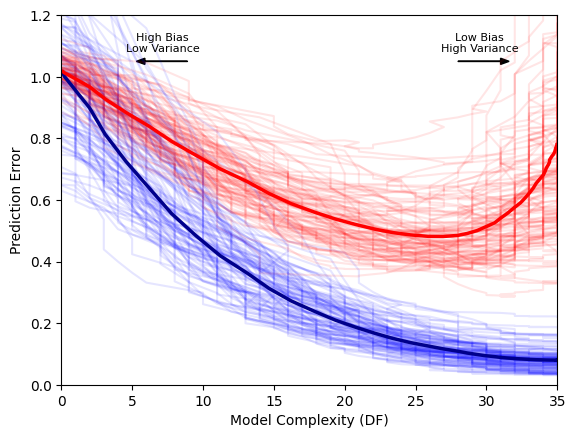

```python
# Parameters
train_size = 50
test_size = 1000
N = train_size + test_size
num_variables = 35
num_iterations = 100
alpha_values = np.logspace(-6, 1, 100)

np.random.seed(7)
sd_X = 1
sd_beta = 0.145
sd_noise = 0.45

train_RSS_all = []
test_RSS_all = []
complexities = []

plt.ylim(0, 1.2)
plt.xlim(0, num_variables)
plt.xlabel('Model Complexity (DF)')
plt.ylabel('Prediction Error')

#population to draw from
beta = np.random.normal(0, sd_beta, size=(num_variables, 1))

for i in range(num_iterations):
    noise = np.random.normal(0, sd_noise, size=(N, 1))
    X = np.random.normal(0, sd_X, size=(N, num_variables))
    Y = X @ beta + noise

    train_X = X[:train_size, :]
    test_X = X[train_size:, :]
    train_Y = Y[:train_size]
    test_Y = Y[train_size:]

    scaler = StandardScaler()
    train_X = scaler.fit_transform(train_X)
    test_X = scaler.transform(test_X)

    train_RSS = []
    test_RSS = []
    complexity = []

    #fitting Lasso for each alpha and calculate RSS
    for alpha in alpha_values:
        model = LassoLars(alpha=alpha, fit_intercept=False)
        model.fit(train_X, train_Y.ravel())

        train_pred = model.predict(train_X)
        test_pred = model.predict(test_X)

        train_RSS.append(mean_squared_error(train_Y, train_pred))
        test_RSS.append(mean_squared_error(test_Y, test_pred))

        complexity.append(np.sum(model.coef_ != 0))

    train_RSS_all.append(train_RSS)
    test_RSS_all.append(test_RSS)
    complexities.append(complexity)

    plt.plot(complexity, train_RSS, alpha=0.1, color="blue")
    plt.plot(complexity, test_RSS, alpha=0.1, color="red")

#calculating average RSS values across all iterations
train_RSS_avg = np.mean(train_RSS_all, axis=0)
test_RSS_avg = np.mean(test_RSS_all, axis=0)
complexity_avg = np.mean(complexities, axis=0)

#plotting averages
plt.plot(complexity_avg, train_RSS_avg, color="darkblue", linewidth=2.5)
plt.plot(complexity_avg, test_RSS_avg, color="red", linewidth=2.5)

#graph annotations
plt.text(7.15, 1.08, 'High Bias\nLow Variance', fontsize=8, ha='center')
plt.arrow(8.9, 1.05, -3, 0, head_width=0.02, head_length=0.6, fc='black', ec='black')
plt.text(29.5, 1.08, 'Low Bias\nHigh Variance', fontsize=8, ha='center')
plt.arrow(28, 1.05, 3, 0, head_width=0.02, head_length=0.6, fc='black', ec='black')

plt.show()
```